# 基本的な機械学習テクニックによるSPAMフィルタリング

## はじめに

- 機械学習を使って簡単なSMS分類器を作ります。
- 時間の制約があるので、このモデルではSMSのコンテンツにのみ焦点を当てることにします。
- Eメール用のモデルを作る場合、より精度を上げるために、Eメールのヘッダー情報や他のメタデータを組み込むことでもっと高度なモデルを作ることができます。

### 機械学習入門

始める前に、機械学習について簡単に説明します。

- 機械学習とは何か？
- どのように機能するのか？
- 機械学習にはどんな種類があるのか？

#### 機械学習とは何か？

**簡単に言うと:**

```
機械学習は人工知能（AI）の一種で、明示的にプログラムすることなく学習する能力をコンピュータに提供するもの。
```

#### 機械学習の種類

機械学習アルゴリズムには3つの種類があります：

- 教師あり学習
- 教師なし学習
- 強化学習

今日は、教師あり学習のみを使用します。それでは、教師あり学習について説明しましょう。

#### 教師あり学習

教師あり学習は、入力と出力がペアになったサンプルに基づいて、入力を出力に対応付ける関数を学習する、機械学習タスクです。教師あり学習は、訓練用サンフルの集合からなるラベル付き訓練データから関数を構築します。

- 最も一般的な機械学習
- 理解しやすい
- 実装が簡単
- 簡単に言えば、子供にフラッシュカードで教えるようなものである。

#### 教師あり学習 (例)

[figure not shown]

メールをスパムと非スパムのカテゴリーに分類するので、教師あり学習を使ってこの問題を解決する方法を見てみましょう。

1. まず、入力データと既知のレスポンスを提供します。(例えば、Eメールかスパムか非スパムか）
2. 次に、モデルにデータとレスポンスの関係を学習させます。
3. 最後に、新しいEメールを入力すると、モデルはそのEメールがスパムかどうかを予測します。

皆さん、教師あり学習の概念には慣れましたか？

**さて、本題のメール分類器の作成に移りましょう。**

- まずは基本的な分析を行います。
- 次にデータのクリーニングと特徴抽出を行います。
- その後、モデルを作成し、評価します。

注意点1：

- このノートブックから Google Colab にコードをコピーペーストします。
- コードセルは順番に実行するようにしてください。

注意点2：

- もし、コードを実行中に何か問題が発生したら、すぐに私か平野さんに連絡してください。
- そうすれば、できるだけ早く修正することができます。そうしないと、コードを実行することも、チュートリアルについていくこともできなくなります。

#### Google Colab.

- ステップ 1: Google Colab を開く
  - まず、 https://colab.research.google.com/ からGoogle Colabを開き、Googleアカウントでログインします。
- ステップ 2: 新しいノートブックを作る
  - ログインしたら、 “ノートブックを新規作成” ボタンをクリックし、新しいノートブックを作ります。

## 1. ライブラリのインストール

まず最初に、このプロジェクトで使用するライブラリをインストールします。

- ライブラリをインストールするにはpipコマンドを使います。(PipはPythonで書かれたソフトウェアパッケージをインストール・管理するためのパッケージ管理システムです。）
- ノートブック内で「%」はシェルコマンドを実行するのに使います。(「!」も使えます）。

```python
%pip install pandas scikit-learn numpy matplotlib seaborn nltk wordcloud xgboost lightgbm
```

## 2. ライブラリのインポート

次に、このプロジェクトで使用するすべてのライブラリをインポートします。

このプロジェクトで使用するライブラリーを簡単な説明とともに列挙してみましょう。

- **numpy** : Numpyは、大規模な多次元配列と行列のサポートを追加するためのライブラリで、これらの配列を操作するための高レベルの数学関数の大規模なコレクションでもある。
- **pandas** : データ操作と分析。
- **matplotlib** : Pythonプログラミング言語とその数値数学拡張NumPy用のプロットライブラリ。
- **seaborn** : Seaborn は matplotlib ベースの Python 可視化ライブラリです。魅力的で情報量の多い統計グラフィックを描画するための高レベルなインターフェースを提供します。
- **sklearn** : Scikit-learnは、Pythonプログラミング言語用の機械学習ライブラリです。
- **nltk** : NLTKは、人間の言語データを扱うPythonプログラムを構築するための主要なプラットフォームです。分類、トークン化、ステミング、タグ付け、構文解析、意味推論のためのテキスト処理ライブラリ群とともに、50以上のコーパスやWordNetなどの語彙リソースへの使いやすいインターフェースを提供します。

```python
# For data manipulation and analysis
import pandas as pd
import numpy as np
import string
from collections import Counter

# For plotting
import matplotlib.pyplot as plt
import seaborn as sns
%matplotlib inline

# For text processing and feature extraction
from sklearn.model_selection import train_test_split
from sklearn.preprocessing import LabelEncoder
from sklearn.feature_extraction.text import TfidfVectorizer

# For text preprocessing and feature extraction
import nltk
from nltk import bigrams
from nltk.corpus import stopwords
from nltk.stem.porter import PorterStemmer
from nltk.tokenize import word_tokenize, sent_tokenize

# Machine learning models and evaluation metrics
from sklearn.naive_bayes import MultinomialNB
from sklearn.linear_model import LogisticRegression
from sklearn.svm import SVC
from sklearn.tree import DecisionTreeClassifier
from sklearn.neighbors import KNeighborsClassifier
from sklearn.ensemble import RandomForestClassifier

from xgboost import XGBClassifier
from lightgbm.sklearn import LGBMClassifier

# Machine learning evaluation metrics
from sklearn.metrics import accuracy_score,confusion_matrix, precision_score, roc_auc_score, f1_score, recall_score

from wordcloud import WordCloud

import warnings
warnings.filterwarnings("ignore")
nltk.download('punkt')
nltk.download('stopwords')
```

```
True
```

## 3. データの読み込みと概要

ライブラリをインポートしたら、次のステップとしてデータセットをインポートする必要があります。

### 3.1. データのロード

- Pandasを使ってデータを取り込み、Dataframeを作成します。
- データフレームは、スプレッドシートやSQLテーブルのようなものだと考えてください。
- データフレームには行と列があり、それぞれの列は独自のデータ型を持つことができます。
- Pandasのクールな点は、ウェブリンクから直接データを取得できることです。今回はこれを使用して、GitHubのリンクからデータを取得します。

```python
# DATA_SET = "./data/spam_dataset.csv"
DATA_SET = "https://raw.githubusercontent.com/qualitia-cdev/hands-on-data/main/spam_dataset.csv"

df = pd.read_csv(DATA_SET, encoding='latin-1')
df.head()
```

|  | v1 | v2 | Unnamed: 2 | Unnamed: 3 | Unnamed: 4 |
| --- | --- | --- | --- | --- | --- |
| 0 | ham | Go until jurong point, crazy.. Available only ... | NaN | NaN | NaN |
| 1 | ham | Ok lar... Joking wif u oni... | NaN | NaN | NaN |
| 2 | spam | Free entry in 2 a wkly comp to win FA Cup fina... | NaN | NaN | NaN |
| 3 | ham | U dun say so early hor... U c already then say... | NaN | NaN | NaN |
| 4 | ham | Nah I don't think he goes to usf, he lives aro... | NaN | NaN | NaN |

### 3.2. データセットの概要

データセットには複数のカラムが含まれているようです：

- **v1**: これはラベルのようで、メッセージが "spam "か "ham"(spamではない)かを示します。
- **v2**:これはsmsメッセージの内容のようです。
- **Unnamed: 2、Unnamed: 3、Unnamed: 4:** これらの列は、最初の数行を見た感じ、ほとんどがNaN（欠損）値になっているようです。

## 4. EDA（探索的データ分析）

### 4.1. EDAとは

- EDAとは、データセットを視覚的・分析的に探索して主な特徴を理解し、パターンを明らかにするプロセスです。
- これは、正式にモデリングする前に行う、データ分析プロセスにおける重要なステップです。

探索的データ分析（EDA）を進めるには：

- 各列の欠損値の数をチェックします。
- スパムメッセージとハムメッセージの数など、データセットの要約を取得します。
- スパムメッセージとスパムメッセージの長さの分布を可視化します。

次の関数は、データセットの要約を得るのに役立ちます。

```python
# basic info about the dataset
df.info()
```

```
<class 'pandas.core.frame.DataFrame'>
RangeIndex: 5572 entries, 0 to 5571
Data columns (total 5 columns):
 #   Column      Non-Null Count  Dtype
---  ------      --------------  -----
 0   v1          5572 non-null   object
 1   v2          5572 non-null   object
 2   Unnamed: 2  50 non-null     object
 3   Unnamed: 3  12 non-null     object
 4   Unnamed: 4  6 non-null      object
dtypes: object(5)
memory usage: 217.8+ KB
```

- データセットには5572のエントリがあります。これは5572のSMSメッセージがあるということです。
- また、unnamed:2、unnamed:3、unnamed:4の列には欠損値が多いことがわかります。
- つまり、これらの列は我々の分析には役に立ちません。

これらの列を削除するには、次のコード・セルを使用します。

```python
# last 3 columns are unnecessary. So we are going to drop them.
df.drop(['Unnamed: 2', 'Unnamed: 3', 'Unnamed: 4'], axis=1, inplace=True)
```

次に、わかりやすいように、データセットのカラム名を変更します。

- *v1*カラムには**ラベル**が、*v2*カラムには**メッセージの本文**が含まれていることがわかります。
- そこで、列の名前をlabelとmessageに変えてみます。
- そして、もう一度データセットをチェックしてみます。

```python
df.rename(columns={'v1': 'label', 'v2': 'message'}, inplace=True)
df.head(10)
```

|  | label | message |
| --- | --- | --- |
| 0 | ham | Go until jurong point, crazy.. Available only ... |
| 1 | ham | Ok lar... Joking wif u oni... |
| 2 | spam | Free entry in 2 a wkly comp to win FA Cup fina... |
| 3 | ham | U dun say so early hor... U c already then say... |
| 4 | ham | Nah I don't think he goes to usf, he lives aro... |
| 5 | spam | FreeMsg Hey there darling it's been 3 week's n... |
| 6 | ham | Even my brother is not like to speak with me. ... |
| 7 | ham | As per your request 'Melle Melle (Oru Minnamin... |
| 8 | spam | WINNER!! As a valued network customer you have... |
| 9 | spam | Had your mobile 11 months or more? U R entitle... |

- 出力結果は、カラムが2つだけになりました。
- また、カラム名がlabelとmessageに変更されています。

### 4.2. 対象変数の分布

- では，ラベル列がデータ集合の中でどのように分布しているかを見てみましょう。
- これの主な目的は、データ集合がバランスよく出来ているかどうかを見るためです。
- データセットのバランスが悪ければ、モデルに偏りが生じる可能性があるためです。

#### ターゲット変数とは何か？

- 機械学習や統計学において、**ターゲット変数** とは、通常「y」で示される変数のことで、データセットの他の特徴から値を予測する変数のことである。

このデータセットでは、**ターゲット変数**は**ラベル**列である。

ターゲット変数の分布を見るために、円グラフを作成しましょう。

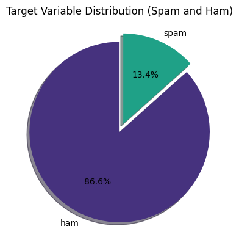

```
ham     4825
spam     747
Name: label, dtype: int64
```

```python
target_cat = df.label.value_counts()

#create pie chart using seaborn
color1 = sns.color_palette("viridis")[0]
color2 = sns.color_palette("viridis")[3]

plt.pie(target_cat, labels=target_cat.index, colors=[color1, color2], autopct='%1.1f%%', shadow=True, startangle=90, explode=(0, 0.1))
plt.title('Target Variable Distribution (Spam and Ham)')
plt.show()

print(target_cat)
```

出力は：

- 「ハム」メッセージは4825通あるが、「スパム」メッセージは747通しかない。
- これは、非常にバランスの悪いデータセットであることを表しています。

データがこのように偏っていると、機械学習モデルは最高のパフォーマンスを発揮できないかもしれません。

不均衡な分布は、訓練とテスト用のデータを分割するときに問題を引き起こす可能性があります。そしてその結果、モデルが多数派のクラスに偏ってしまいます。

これを処理する方法はいくつかある。しかし、物事をシンプルにするために、ランダムに "ハム"メッセージを削除して、バランスさせます。

これを行った後、もう一度ターゲット変数の分布を見てみましょう。

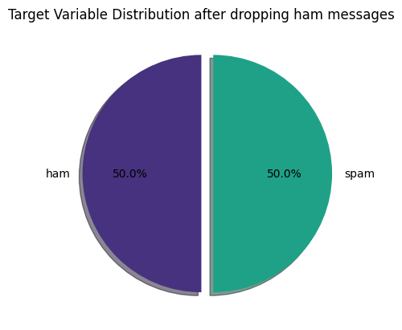

```
ham     747
spam    747
Name: label, dtype: int64
```

```python
num_spam = target_cat['spam']

# Randomly sampling the majority class to match the count of the minority class
df = pd.concat(
    [
        df[df['label'] == 'ham'].sample(n=num_spam, random_state=42),
        df[df['label'] == 'spam']
    ]
)

#check the target variable distribution again
target_cat = df.label.value_counts()

#set the colors
color1 = sns.color_palette("viridis")[0]
color2 = sns.color_palette("viridis")[3]

#plot the pie chart
plt.pie(target_cat, labels=target_cat.index, colors=[color1, color2], autopct='%1.1f%%', shadow=True, startangle=90, explode=(0, 0.1))
plt.title('Target Variable Distribution after dropping ham messages')
plt.show()

print(target_cat)
```

これで、ハムとスパムの割合と通数が同じであることがわかります。では、次のステップに進んでみましょう。

### 4.3. スパムメッセージとハムメッセージで最もよく使われる単語（ユニグラム）

- スパムメッセージとハムメッセージで最もよく使われるユニグラムを見ることで、スパムメッセージとハムメッセージでどの単語がより頻繁に使われているかを知ることができます。
- また、これはデータをよりよく理解するのに役立ちます。

**ユニグラムとは？**

- ユニグラムとは、文中の個々の単語のこと。
- 例えば、"I love Python "という文には3つのユニグラムがあります： I"、"love"、"Python "

次のコード・セルでは、スパムメッセージとハムメッセージで上位10個のユニグラムを取得します。 また、スパムメッセージに含まれるユニグラムの数がどのように見えるかをチェックします。

```python
# We'll use a predefined list of stopwords as we can't download them directly here
# stop_words = set([
#     "ourselves", "hers", "between", "yourself", "but",
#     "again", "there", "about", "once", "during", "out",
#     "very", "having", "with", "they", "own", "an", "be",
#     "some", "for", "do", "its", "yours", "such", "into",
#     "of", "most", "itself", "other", "off", "is", "s", "am",
#     "or", "who", "as", "from", "him", "each", "the", "themselves",
#     "until", "below", "are", "we", "these", "your", "his", "through",
#     "don", "nor", "me", "were", "her", "more", "himself", "this",
#     "down", "should", "our", "their", "while", "above", "both", "up",
#     "to", "ours", "had", "she", "all", "no", "when", "at", "any", "before",
#     "them", "same", "and", "been", "have", "in", "will", "on", "does",
#     "yourselves", "then", "that", "because", "what", "over", "why", "so",
#     "can", "did", "not", "now", "under", "he", "you", "herself", "has",
#     "just", "where", "too", "only", "myself", "which", "those", "i",
#     "after", "few", "whom", "t", "being", "if", "theirs", "my", "against",
#     "a", "by", "doing", "it", "how", "further", "was", "here", "than"
# ])

#get the stopwords from nltk
stop_words = set(stopwords.words('english'))

def get_most_common_words(texts, n=10):
    words = []
    for text in texts:
        tokens = word_tokenize(text)
        words.extend([word.lower() for word in tokens if word.isalpha() and word.lower() not in stop_words])
    # Count the frequency of each word
    word_freq = Counter(words)

    return word_freq.most_common(n)

# Get the 10 most common words for spam and ham messages
common_words_ham = get_most_common_words(df[df['label'] == 'ham']['message'], 10)
common_words_spam = get_most_common_words(df[df['label'] == 'spam']['message'], 10)


#create table to for common_words_ham, common_words_spam
common_words_ham_df = pd.DataFrame(common_words_ham, columns=['word', 'count'])
common_words_spam_df = pd.DataFrame(common_words_spam, columns=['word', 'count'])

common_words_spam_df.head(10)
```

|  | word | count |
| --- | --- | --- |
| 0 | call | 346 |
| 1 | free | 219 |
| 2 | txt | 156 |
| 3 | u | 144 |
| 4 | ur | 144 |
| 5 | mobile | 123 |
| 6 | text | 121 |
| 7 | stop | 114 |
| 8 | claim | 113 |
| 9 | reply | 104 |

- スパムメッセージの中で最も一般的なユニグラムは「call」であることがわかります。他にもいくつかの単語があります。
- データの概要を把握するためのより良い方法は、ワードクラウド(Word Cloud)を作成することである。
- ワードクラウド(Word Cloud)はテキストデータを表現するために使われるデータ可視化技術で、各単語の**大きさがその頻度**や重要度を示します。

それでは、スパムメールと迷惑メールのワードクラウド(Word Cloud)を作ってみましょう。

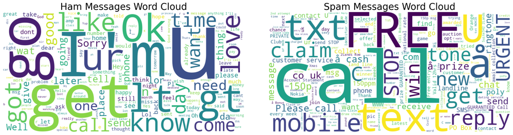

```python
def generate_wordcloud(texts_ham, texts_spam):

    # Join all the text messages together
    all_text_ham = ' '.join(texts_ham)
    all_text_spam = ' '.join(texts_spam)

    # Create a word cloud for ham and spam messages
    wordcloud_ham = WordCloud(stopwords=stop_words, background_color="white", width=800, height=400).generate(all_text_ham)
    wordcloud_spam = WordCloud(stopwords=stop_words, background_color="white", width=800, height=400).generate(all_text_spam)

    # Plot the word clouds
    fig, (ax1, ax2) = plt.subplots(1, 2, figsize=(20, 5))
    ax1.imshow(wordcloud_ham, interpolation='bilinear')
    ax1.axis('off')
    ax1.set_title("Ham Messages Word Cloud", fontsize=25)

    ax2.imshow(wordcloud_spam, interpolation='bilinear')
    ax2.axis('off')
    ax2.set_title("Spam Messages Word Cloud", fontsize=25)

    # Adjust layout
    plt.tight_layout()
    plt.show()

# Generate word clouds for ham and spam messages side by side
generate_wordcloud(df[df['label'] == 'ham']['message'].tolist(), df[df['label'] == 'spam']['message'].tolist())
```

- **ハム・メッセージのワードクラウド：**
  - 非スパムメッセージで目立つ言葉には、"I'm"、"u"、"know"、"get"、"Ok"、"love"、"go"などがあります。
  - これらの単語は、カジュアルまたはインフォーマルな会話を示しています。
- **スパムメッセージのワードクラウド**:
  - スパムメッセージには、「free(無料)」、「call(電話)」、「text(テキスト)」、「mobile(携帯電話)」、「reply(返信)」、「urgent(緊急)」、「claim(クレーム)」といった言葉が目立ちます。
  - これらの単語は、しばしば宣伝や詐欺的な内容と関連しています。

### 4.4. スパムとハムメッセージで最もよく使われるバイグラム

上でスパムメッセージとハムメッセージに最もよく見られるユニグラムについて見ました。次に、最も一般的なバイグラムについて見てみましょう。

#### バイグラムとは？

テキスト分析におけるバイグラムとは、与えられたテキスト中の連続する単語のペアのことです。

例: "I love ice cream"という文章の場合、バイグラムだと以下のようになります。:

- I love
- love ice
- ice cream

スパムとハムメッセージで最もよく使われるバイグラムを見てみましょう。

- 次のコードでは、まずスパムメッセージとハムメッセージから上位10個のバイグラムを抽出します。
- 最後に、バイグラムを棒グラフにプロットします。

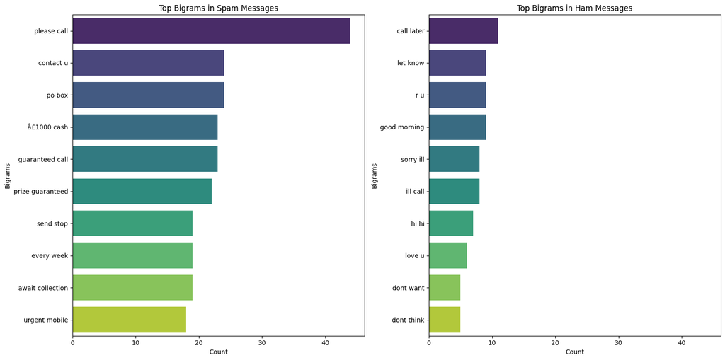

```python
def remove_punctuation(message):
    return ''.join([char for char in message if char not in string.punctuation])


def tokenize(message):
    return [word.lower() for word in message.split() if word.lower() not in stop_words]


def generate_bigrams(tokens):
    return list(bigrams(tokens))


def preprocess_message(message):
    message = remove_punctuation(message)
    tokens = tokenize(message)
    return generate_bigrams(tokens)


def get_top_bigrams(series, n=10):
    # Flatten the list of bigrams and count occurrences
    all_bigrams = [bigram for sublist in series for bigram in sublist]
    bigram_counts = Counter(all_bigrams)
    return bigram_counts.most_common(n)

def plot_top_bigrams(df, column, title, ax, palette="viridis"):
    sns.barplot(data=df, y=column, x='Count', ax=ax, palette=palette)
    ax.set_title(title)
    ax.set_xlabel('Count')
    ax.set_ylabel(column)

# Assuming your original DataFrame is loaded as 'df'
df["bigrams"] = df["message"].apply(preprocess_message)

# Extract top bigrams
top_spam_bigrams = get_top_bigrams(df[df['label'] == 'spam']['bigrams'])
top_ham_bigrams = get_top_bigrams(df[df['label'] == 'ham']['bigrams'])

# Create dataframes for visualization
spam_df = pd.DataFrame(top_spam_bigrams, columns=['Bigrams', 'Count'])
ham_df = pd.DataFrame(top_ham_bigrams, columns=['Bigrams', 'Count'])

# Adjust bigram representation for readability
spam_df['Bigrams'] = spam_df['Bigrams'].apply(lambda x: ' '.join(x))
ham_df['Bigrams'] = ham_df['Bigrams'].apply(lambda x: ' '.join(x))

# Create subplots
fig, axes = plt.subplots(1, 2, figsize=(16, 8), sharex=True)
plot_top_bigrams(spam_df, 'Bigrams', 'Top Bigrams in Spam Messages', axes[0])
plot_top_bigrams(ham_df, 'Bigrams', 'Top Bigrams in Ham Messages', axes[1])

plt.tight_layout()
plt.show()
```

上のグラフから、次のことがわかります：

- スパムメッセージには、"please call"（電話してください）、"contact u"（連絡します）、"await collection"（回収を待っています）など、受信者に行動を促す文言が頻繁に含まれています。
- 一方、非スパムメッセージは、「call later(後で電話する)」、「let know(知らせる)」、「good morning(おはよう)」などのフレーズで、日常会話を中心に展開されているようです。

## 5. 特徴量エンジニアリング

### 特徴量エンジニアリングとは？

特徴量エンジニアリングとは、機械学習モデルの性能を向上させるために、データについて既知の情報をもとに追加の特徴量を作成することです。

#### 5.1. メッセージの長さ

- 次に、スパムメールとスパムメールのメッセージの長さの分布を可視化してみましょう。
- これにより、スパムメッセージとそうでないメッセージの長さに顕著な違いがあるかどうかを知ることができます。

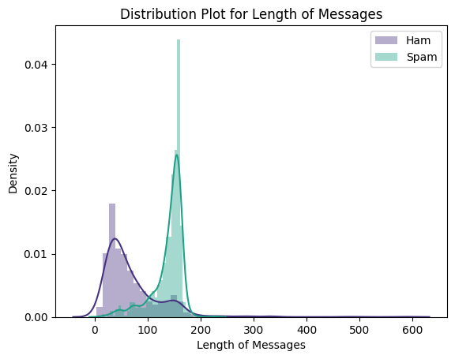

```
Average message length for ham messages:  69.11780455153949
Average message length for spam messages:  138.8661311914324
```

```python
# create a new column for message length and calculate the length of each message
df["msg_len"] = df["message"].apply(len)

# Plot the distribution of message lengths
sns.distplot(df[df.label == 'ham'].msg_len, label='Ham', color=sns.color_palette("viridis")[0])
sns.distplot(df[df.label == 'spam'].msg_len, label='Spam', color=sns.color_palette("viridis")[3])
plt.title('Distribution Plot for Length of Messages')
plt.xlabel('Length of Messages')
plt.legend()
plt.show()

print('Average message length for ham messages: ', df[df['label'] == 'ham']['message'].str.len().mean())
print('Average message length for spam messages: ', df[df['label'] == 'spam']['message'].str.len().mean())
```

#### 5.2 その他の特徴量

時間が限られているため、各機能を説明することなく、すべての特徴量を一度に作成します。

**しかし、実際のプロジェクトでは、各特徴量を分析し、使用するかどうかを決定する必要があります。**

先ほどと同じようなアプローチで、次のような特徴量を作ることができます：

- 句読点の数
- 感嘆符の数
- 大文字の数
- 数字の桁数
- 文の数
- 単語の数

次のコード・セルは、上記のすべての特徴量を作成します。

```python
# Create new column for number of punctuations, and calculate the number of punctuations in each message
df['num_punctuations'] = df['message'].apply(lambda x: sum([1 for char in x if char in string.punctuation]))

# Create new column for number of exclamation marks, and calculate the number of exclamation marks in each message
df['num_exclamation_marks'] = df['message'].apply(lambda x: sum([1 for char in x if char == '!']))

# Calculate the  number of uppercase letters in each message and create a new column for it
df['num_upper_case'] = df['message'].apply(lambda x: sum([1 for char in x if char.isupper()]))

# Count the number of numeric characters in each message and create a new column for it
df['num_numeric'] = df['message'].apply(lambda x: sum([1 for char in x if char.isdigit()]))

# Tokenize messages and compute the number of sentences in each message and create a new column for it
df['num_sentences'] = df['message'].apply(lambda x: len(sent_tokenize(x)))

# Create a new column for number of words in each message and calculate the number of words in each message
df['num_words'] = df['message'].apply(lambda x: len(word_tokenize(x)))
```

## 6 モデルのトレーニング

#### 6.1. 特徴量の選択

- スパム検出のための効果的な機械学習モデルを構築するには、**注意深く選択された特徴量**が必要です。
- 実際のプロジェクトでは、各特徴量を分析し、使用するかどうかを決定する必要があります。
- しかし、時間が限られているため、前のステップで作成した全ての特徴を使用することにします。

データフレームの現在のカラムを確認してみましょう。

```python
df.columns
```

```
Index(['label', 'message', 'bigrams', 'msg_len', 'num_punctuations',
       'num_exclamation_marks', 'num_upper_case', 'num_numeric',
       'num_sentences', 'num_words'],
      dtype='object')
```

- 上の出力を見ると、使用する特徴量がすでに作成されていることがわかります。
- 次のステップでは、特徴量を変数に代入します。(X)

**注意点**

- X: これは独立変数の行列です。
  - メッセージの様々な特徴を表すデータフレームの列が含まれます。
  - 例えば、メッセージの長さ (msg_len)、感嘆符の数 (num_exclamation_marks)などです。

```python
X = df[['msg_len', 'num_exclamation_marks', 'num_punctuations', 'num_upper_case', 'num_numeric', 'num_words', 'num_sentences']]
```

#### 6.2. ラベルのエンコード

- 多くの機械学習アルゴリズムでは、カテゴリラベル（または特徴量）を数値に変換する必要があります。
- アルゴリズムは数値を扱うように設計されているからです。

- この処理は 「エンコード 」と呼ばれます。

このデータセットでは、ラベル列をエンコードする必要があります。

たとえば

- スパム 1
- ハム：0

次のコードセルはラベル列をエンコードします。

```python
encoder = LabelEncoder()
encoded_labels = encoder.fit_transform(df['label'])
df['encoded_label'] = encoded_labels
df.tail()
```

|  | label | message | bigrams | msg_len | num_punctuations | num_exclamation_marks | num_upper_case | num_numeric | num_sentences | num_words | encoded_label |
| --- | --- | --- | --- | --- | --- | --- | --- | --- | --- | --- | --- |
| 5537 | spam | Want explicit SEX in 30 secs? Ring 02073162414... | [(want, explicit), (explicit, sex), (sex, 30),... | 90 | 3 | 1 | 17 | 21 | 3 | 18 | 1 |
| 5540 | spam | ASKED 3MOBILE IF 0870 CHATLINES INCLU IN FREE ... | [(asked, 3mobile), (3mobile, 0870), (0870, cha... | 160 | 5 | 0 | 104 | 14 | 6 | 38 | 1 |
| 5547 | spam | Had your contract mobile 11 Mnths? Latest Moto... | [(contract, mobile), (mobile, 11), (11, mnths)... | 160 | 8 | 1 | 20 | 2 | 5 | 35 | 1 |
| 5566 | spam | REMINDER FROM O2: To get 2.50 pounds free call... | [(reminder, o2), (o2, get), (get, 250), (250, ... | 147 | 3 | 0 | 14 | 5 | 1 | 30 | 1 |
| 5567 | spam | This is the 2nd time we have tried 2 contact u... | [(2nd, time), (time, tried), (tried, 2), (2, c... | 161 | 8 | 1 | 9 | 21 | 4 | 35 | 1 |

- encoded_labelという新しいカラムがデータフレームに追加されているのがわかります。
- このカラムにはエンコードされたラベルが含まれています。

ターゲット変数がどのようにエンコードされているか確認してみましょう。

```python
# Display classes and their encoded values
for original, encoded in zip(encoder.classes_, range(len(encoder.classes_))):
    print(f"'{original}' is encoded as {encoded}")
```

```
'ham' is encoded as 0
'spam' is encoded as 1
```

- スパムは1、ハムは0とエンコードされていることがわかります。

エンコードされたラベルを変数に代入します。(y)

**注意点**

- y: これは、応答変数または従属変数で、この場合はencoded_labelです。
  - これは、メッセージがスパムかどうかをエンコードした形で表す。（例えば、'ham'は0、'spam'は1）

```python
y = df["encoded_label"]
```

### 6.3. データの分割

機械学習では、データをトレーニングセットとテストセットに分割する必要があります。

#### トレーニングセットとテストセットとは？

- トレーニングセットとは、モデルをトレーニングするためのデータセットです。
- テストセットとは、テストセット上でモデルがどの程度の予測を行うことができるかを測定するために使用されるデータセットです。

**次のコードでは、データをトレーニングセットとテストセットに分割します。**

```python
X_train, X_test, y_train, y_test = train_test_split(X, y, test_size=0.3, random_state=42)
```

### 6.4. 機械学習モデル

- 分類に使用できる機械学習アルゴリズムは数多くあります。
  - ランダム・フォレスト(Random Forest)
  - ロジスティック回帰(Logistic Regression)
  - サポートベクターマシン(Support Vector Machine)
  - など
- ほとんどの場合、どのアルゴリズムが我々のデータセットで最高のパフォーマンスを発揮するかはわかりません。
- そこで、さまざまなアルゴリズムを試して、その性能を比較する必要があります。

様々なアルゴリズムを試して、そのパフォーマンスを比較してみましょう。

機械学習アルゴリズムの辞書を作ってみます。

それぞれのアルゴリズムについて簡単に説明します。

- **ランダムフォレスト(Random Forest)**： 汎用性の高いアンサンブル手法で、学習中に複数の決定木を作成し、分類タスクのクラスのモードを出力する。ここでは1000本の木を作成しています。
- **デシジョンツリー(Decision Tree)**：フローチャートのような構造で、各内部ノードは特徴（または属性）を表し、各ブランチはデシジョンルールを表し、各リーフノードは結果を表します。
- **ロジスティック回帰(Logistic Regression)**： 結果を決定する1つ以上の独立変数が存在するデータセットを分析するための統計的手法。
- **SVC(サポート・ベクトル分類器/Support Vector Classifier)**： サポート・ベクトル・マシン（SVM）ファミリーの一部で、分類に使用される。ここでは線形カーネルを使用します。
- **KNN(K-Nearest Neighbors)**： 分類と回帰に使用されるノンパラメトリックアルゴリズム。デフォルトでは5近傍を考慮する。
- **XGB(XGBoost)**： 最適化された勾配ブースティング・ライブラリ。目的語を'binary:hinging'に設定することで、バイナリ分類問題に有効です。
- **多項式NB(Multinomial Naive Bayes):** Naive Bayes分類器の一種で、特に離散特徴による分類に適しています。
- **LGBM(Light Gradient Boosted Machine):** ツリーベースの学習アルゴリズムを使用する勾配ブースティングのフレームワーク。ここでは2値分類用に設定されています。

```python
num_feat_models = {
    "Random Forest": RandomForestClassifier(n_estimators=1000, random_state=42),
    "Decision Tree": DecisionTreeClassifier(random_state=42),
    "Logistic Regression": LogisticRegression(random_state=42),
    "SVC": SVC(kernel="linear", random_state=42),
    "KNN" : KNeighborsClassifier(),
    "XGB": XGBClassifier(objective='binary:hinge', random_state=42),
    "Multinomial NB": MultinomialNB(),
    "LGBM" : LGBMClassifier(boosting_type='gbdt',objective='binary', max_depth=4, random_state=42, verbose=-1)

}
```

### 6.5. モデルのトレーニング

プロジェクトの最終段階に来ました。モデルのトレーニングです。

- 次のコードでは、トレーニングデータを使ってモデルをトレーニングし、テストデータを使ってモデルを評価します。

```python
def train_clf(model, X_train, y_train, X_test, y_test):
    # Train the model
    model.fit(X_train, y_train)

    # Make predictions and get accuracy and precision
    y_pred = model.predict(X_test)

    results = {
        'Accuracy': accuracy_score(y_test, y_pred),
        'Precision': precision_score(y_test, y_pred),
        'Recall': recall_score(y_test, y_pred),
        'F1 Score': f1_score(y_test, y_pred),
        'Roc Auc Score': roc_auc_score(y_test, y_pred),
        'Confusion Matrix': confusion_matrix(y_test, y_pred)
    }

    return results

# Store scores for each model
model_scores = {}

for name, model in num_feat_models.items():
    model_scores[name] = train_clf(model, X_train, y_train, X_test, y_test)

# Convert scores dictionary to a DataFrame
scores_df = pd.DataFrame(model_scores).T
scores_df.reset_index(inplace=True)
scores_df.rename(columns={'index': 'Algorithm'}, inplace=True)
scores_df = scores_df.sort_values(by="F1 Score", ascending=False)
```

### 6.6. モデルの評価

では、モデルの性能をチェックしてみましょう。

```python
scores_df
```

|  | Algorithm | Accuracy | Precision | Recall | F1 Score | Roc Auc Score | Confusion Matrix |
| --- | --- | --- | --- | --- | --- | --- | --- |
| 0 | Random Forest | 0.973274 | 0.986726 | 0.961207 | 0.973799 | 0.973691 | [[214, 3], [9, 223]] |
| 7 | LGBM | 0.966592 | 0.977974 | 0.956897 | 0.96732 | 0.966928 | [[212, 5], [10, 222]] |
| 5 | XGB | 0.962138 | 0.969432 | 0.956897 | 0.963124 | 0.962319 | [[210, 7], [10, 222]] |
| 1 | Decision Tree | 0.957684 | 0.965066 | 0.952586 | 0.958785 | 0.95786 | [[209, 8], [11, 221]] |
| 4 | KNN | 0.955457 | 0.969027 | 0.943966 | 0.956332 | 0.955854 | [[210, 7], [13, 219]] |
| 2 | Logistic Regression | 0.953229 | 0.968889 | 0.939655 | 0.954048 | 0.953699 | [[210, 7], [14, 218]] |
| 3 | SVC | 0.951002 | 0.972973 | 0.931034 | 0.951542 | 0.951692 | [[211, 6], [16, 216]] |
| 6 | Multinomial NB | 0.919822 | 0.962264 | 0.87931 | 0.918919 | 0.921222 | [[209, 8], [28, 204]] |

- 分類モデルの性能を評価する指標はいくつかあります。
- ここでは混同行列(Confusion Matrix)に注目する。

時間が限られているため、それぞれのメトリクスについて説明するつもりはありません。知っておくべきことは

- **True PositiveとTrue Negativeが高いほど、False PositiveとFalse Negativeが低いほど、そのモデルは優れている。**
- **F1スコアが高いほど、良いモデルである。**

上記の出力から、以下のことがわかります：

- **ランダムフォレスト(Random Forest)** が最もF1スコアが高い。

**スコア**

1. True Positive (TP):
   - 意味： ポジティブと予測され、実際にポジティブであった事例の数。
2. True Negative (TN):
   - 意味： ネガティブと予測され、実際にネガティブであった事例の数。
3. False Positive (FP) - 別名I型エラー:
   - 意味: Positiveと予測されたが実際にはNegativeであった事例の数。
   - 一般に「誤報(False Alarm)」と呼ばれる。
4. False Negative (FN) - 別名II型エラー:
   - 意味: Negativeと予測されたが実際にはPositiveであった事例の数。
   - これは 「見逃し検知(Missed Detection)」と考えられる。

これらの4つの尺度は、しばしば混同行列(Confusion Matrix)として知られるものに一緒に表示されます。これらの用語は、Accuracy、Precision、Recall、F1スコアのような、分類における他の多くのパフォーマンス・メトリクスの基礎を形成するため、これらの用語を理解することは非常に重要です。

- Accuracy = (TP + TN) / (TP + TN + FP + FN)
- Precision = TP / (TP + FP)
- Recall (または 感度(Sensitivity) または True Positive率) = TP / (TP + FN)
- F1 Score = 2 * (Precision * Recall) / (Precision + Recall)

**私たちが知っておかなければならないのは、Accuracy(精度)が高ければ高いほど良いモデルだということです。**

次のコード・セルは、各モデルの混同行列(Confusion Matrix)をプロットします。

[figure not shown]

```python
# Plot
classes = ['ham', 'spam']

fig, axes = plt.subplots(nrows=2, ncols=4, figsize=(20, 10))
for idx, ax in enumerate(axes.flatten()):
    algo = scores_df.iloc[idx]['Algorithm']
    cm = scores_df.iloc[idx]['Confusion Matrix']
    # Prepare the labels for each cell
    labels = np.array([["TP: " + str(cm[0, 0]), "FP: " + str(cm[0, 1])],
                       ["FN: " + str(cm[1, 0]), "TN: " + str(cm[1, 1])]])

    sns.heatmap(cm, annot=labels, fmt="", cmap="Blues", ax=ax, cbar=False)

    ax.set_title(algo)

    ax.set_xticklabels(classes)
    ax.set_yticklabels(classes, rotation=0)

    ax.set_xlabel('Predicted labels')
    ax.set_ylabel('True labels')

plt.tight_layout()
plt.show()
```

- ランダムフォレストモデルは、True PositiveとTrue Negative の数が最も多く、False Positive と False Negativeの数が最も少ないことがわかります。
- これは、ラランダムフォレストモデルがすべてのモデルの中で最も高い精度を持つことを意味します。

### 7.6. 新しいデータの予測

では、数値特徴に基づくモデルを使って新しいメッセージを予測してみよう。

### 予測の流れ

- 新しいメッセージの特徴を作成する必要がある。
- そして、そのモデルを使って新しいメッセージを予測します。
- 新しいメッセージを予測するために、いくつかのメッセージの例を使います。

要約すると、以下のコードは新しいメッセージの数値特徴を作成し、すべてのモデルを使って予測します。各モデルの予測値を比較することができます。

```python
def extract_numerical_features(message):
    features = {
        'msg_len': len(message),
        'num_exclamation_marks': message.count('!'),
        'num_punctuations': sum(1 for char in message if char in string.punctuation),
        'num_upper_case': sum(1 if char.isupper() else 0 for char in message),
        'num_numeric': sum(1 if char.isdigit() else 0 for char in message),
        'num_words': len(word_tokenize(message)),
        'num_sentences': len(sent_tokenize(message))
    }
    return features

def predict_new_data(message, num_feat_models, encoder):
    # Extract features
    features = extract_numerical_features(message)

    # Convert to dataframe
    df = pd.DataFrame(features, index=[0])

    # Dictionary to store the results
    predictions = {}

    for model_name, model in num_feat_models.items():
        pred = model.predict(df)
        # Assuming encoder.inverse_transform(pred) returns a list of class labels
        predicted_class = encoder.inverse_transform(pred)[0]
        predictions[model_name] = predicted_class

    return predictions

def compare_predictions(text_samples, num_feat_models, encoder):
    for text in text_samples:
        print(f"Predicting for: {text}")
        predictions = predict_new_data(text, num_feat_models, encoder)

        # Print individual model predictions
        for model, pred in predictions.items():
            print(f"{model} predicted: {pred}")

        # Check if all model predictions are the same; if not, compare the results
        unique_predictions = set(predictions.values())

        if len(unique_predictions) == 1:
            print("All models agree on the prediction.")
        else:
            print("Models made different predictions.")

        print("----------")

# Usage:
text_samples = [
    "Congratulations! You have won a $1000 Walmart gift card. Click here to claim: https://bit.ly/3kceqyh",
    "Hey, how are you doing? Let's meet up soon!"
]

# Assuming 'num_feat_models' is a dictionary of your models and 'encoder' is your label encoder
print("Comparing predictions on new data using numeric features model")
compare_predictions(text_samples, num_feat_models, encoder)
```

```
Comparing predictions on new data using numeric features model
Predicting for: Congratulations! You have won a $1000 Walmart gift card. Click here to claim: https://bit.ly/3kceqyh
Random Forest predicted: spam
Decision Tree predicted: spam
Logistic Regression predicted: spam
SVC predicted: spam
KNN predicted: ham
XGB predicted: spam
Multinomial NB predicted: spam
LGBM predicted: spam
Models made different predictions.
----------
Predicting for: Hey, how are you doing? Let's meet up soon!
Random Forest predicted: ham
Decision Tree predicted: ham
Logistic Regression predicted: ham
SVC predicted: ham
KNN predicted: ham
XGB predicted: ham
Multinomial NB predicted: ham
LGBM predicted: ham
All models agree on the prediction.
----------
```

### 8. モデルのパフォーマンスを向上させるには

- モデルを訓練するデータを増やす。
- モデルを訓練するための特徴量を増やす。
- 複数のアルゴリズムを組み合わせることで、モデルの性能を向上させることができる。(アンサンブル学習(Ensemble Learning)）
- 数値特徴とテキスト特徴を組み合わせてモデルを訓練する。
- ディープラーニングアルゴリズム(Deep Learning Algorithms)のような、より高度なアルゴリズムを使用する。

### 9. 結論

- このプロジェクトでは、メールをスパムかハム(非スパム)か分類する機械学習モデルを構築しました。
- 以下のようなことに慣れました
  - 機械学習
  - 教師あり学習
  - EDA（探索的データ分析）
  - 特徴工学
  - モデル学習
  - モデルの評価
- モデルの訓練にはいくつかの機械学習アルゴリズムを使用しました。
- ランダムフォレストモデルは、このデータセットとタスクに対して、全てのモデルの中で最高のパフォーマンスを示しました。